# Tapia_Bruno_A1

## Kaggle Submission Template

#### DAT-5390 | Computational Data Analytics with Python

Chase Kusterer - Faculty of Analytics  
Hult International Business School

### The Purpose of the Notebook

This Notebook is organized as a template for submitting on Kaggle. It will output a .csv file that can be submitted via Kaggle.  
Remember that you also need to provide an analysis alongside your model building via the assignment link on the course page. Start by conducting your analysis and then copy/paste relevant code to this template (missing value imputation, feature engineering, etc.). Please do not submit this template as your analysis (many of the technical steps are not necessary for the analysis). Finally, on the course page, make sure to submit your analysis and model development as one document in two formats (Jupyter Notebook and a .txt file).

### Reminder: Model Analysis Tips

**How fit should a model be?**  
As a general heuristic, if the training and testing scores are within 0.05 of each other, the model has not been overfit. Don't worry if the testing score ends up higher than the training score. Some sources claim that in such situations a model is underfit, but this is a general misconception that is beyond the scope of this course. For this course, long as the training and testing scores are within 0.05 of each other, the model is good to go.

**Which model should I choose?**  
All models have their own benefits and drawbacks. Thus, it is important to test out more than one and to also explore their [documentation](https://scikit-learn.org/stable/modules/classes.html#classical-linear-regressors).

## Part I: Imports and Data Check

```python
## importing libraries ##

# for this template
import numpy             as np                       # mathematical essentials
import pandas            as pd                       # data science essentials
import sklearn.linear_model                          # linear models
from sklearn.model_selection import train_test_split # train/test split
from sklearn.linear_model import SGDRegressor
from sklearn.linear_model import LinearRegression



#!###############################!#
#!# import additional libraries #!#
#!###############################!#
# import whatever you need
import seaborn as sns                                  # enhanced data viz
import statsmodels.formula.api as smf                  # linear modeling
from sklearn.neighbors import KNeighborsRegressor      # KNN for Regression
from sklearn.preprocessing import StandardScaler
import matplotlib.pyplot as plt                        # data viz
from sklearn.tree import DecisionTreeRegressor         # regression trees
from sklearn.model_selection import RandomizedSearchCV # hyperparameter tuning
import warnings                                        # warnings from code
from sklearn.tree import plot_tree



# setting pandas print options (optional)
pd.set_option('display.max_rows', 500)
pd.set_option('display.max_columns', 500)
pd.set_option('display.width', 1000)
```

```python
## importing data ##

# reading modeling data into Python
modeling_data = './datasets/train.xlsx'

# calling this df_train
df_train = pd.read_excel(io         = modeling_data,
                         sheet_name = 'data',
                         header     = 0,
                         index_col  = 'ID')



# reading testing data into Python
testing_data = './datasets/test.xlsx'

# calling this df_test
df_test = pd.read_excel(io         = testing_data,
                        sheet_name = 'data',
                        header     = 0,
                        index_col  = 'ID')
```

```python
# concatenating datasets together for mv analysis and feature engineering
df_train['set'] = 'Not Kaggle'
df_test ['set'] = 'Kaggle'

# concatenating both datasets together for mv and feature engineering
df_full = pd.concat(objs = [df_train, df_test],
                    axis = 0,
                    ignore_index = False)


# checking data
df_full.head(n = 5)
```

| ID | DateHour | Temperature(F) | Humidity(%) | Wind speed (mph) | Visibility(miles) | DewPointTemperature(F) | Rainfall(in) | Snowfall(in) | SolarRadiation(MJ/m2) | Holiday | FunctioningDay | RENTALS | set |
| --- | --- | --- | --- | --- | --- | --- | --- | --- | --- | --- | --- | --- | --- |
| mb_1039 | 2023-10-14 05:59:54.810000 | 52 | 81 | 0.4 | 2.9 | 46.4 | 0.0 | 0.0 | 0.00 | No | Yes | 519.0 | Not Kaggle |
| mb_1330 | 2023-10-26 08:59:53.355000 | 51 | 53 | 2.2 | NaN | 35.2 | 0.0 | 0.0 | 1.01 | No | Yes | 1251.0 | Not Kaggle |
| mb_551 | 2023-09-23 21:59:57.250000 | 56 | 49 | 2.5 | 3.4 | 38.8 | 0.0 | 0.0 | 0.00 | No | Yes | 1685.0 | Not Kaggle |
| mb_2103 | 2023-12-19 14:00:00 | 69 | 32 | 9.8 | 12.4 | 38.7 | 0.0 | 0.0 | 2.36 | No | No | 0.0 | Not Kaggle |
| mb_1430 | 2023-10-30 12:59:52.855000 | 53 | 20 | 2.9 | 10.8 | 12.9 | 0.0 | 0.0 | 1.96 | No | Yes | 814.0 | Not Kaggle |

```python
# checking available features
df_full.columns
```

```
Index(['DateHour', 'Temperature(F)', 'Humidity(%)', 'Wind speed (mph)', 'Visibility(miles)', 'DewPointTemperature(F)', 'Rainfall(in)', 'Snowfall(in)', 'SolarRadiation(MJ/m2)', 'Holiday', 'FunctioningDay', 'RENTALS', 'set'], dtype='object')
```

## Part II: Data Preparation

Complete the following steps to prepare for model building. Note that you may add or remove steps as you see fit. Please see the assignment description for details on what steps are required for this project.

# Introduction

The bike rental industry has increased in recent years due to several factors and it is estimated that it will continue with a sustained increase until 2030, mainly e-bikes that allow greater mobility while preserving sustainability. In this dataset, we initially started with 13 columns and 2184 entries, including a unique identifier ID, and a SET identifier to maintain a separation in the different sets. In the dataset, we have nine numeric variables and four categorical variables, including the DateHour variable that is a date record and in which the information was collected, FunctioningDay that determines whether the operating system is active on a specific day and Holiday that determines a period of time set aside for festivals or recreation.

# Exploratory data analysis

By using the .info() function we can notice that there are three different columns with missing values, Visibility(miles), DewPointTemperature(F) and SolarRadiation(MJ/m2 that must be treated before building the model, as well as the variable DateHour, which must be transformed to a proper date and time format for further analysis. The variable RENTALS is our variable to predict.

```python
df_full.info()
```

```
<class 'pandas.core.frame.DataFrame'>
Index: 2184 entries, mb_1039 to mb_1225
Data columns (total 13 columns):
 #   Column                  Non-Null Count  Dtype
---  ------                  --------------  -----
 0   DateHour                2184 non-null   object
 1   Temperature(F)          2184 non-null   int64
 2   Humidity(%)             2184 non-null   int64
 3   Wind speed (mph)        2184 non-null   float64
 4   Visibility(miles)       2108 non-null   float64
 5   DewPointTemperature(F)  2117 non-null   float64
 6   Rainfall(in)            2184 non-null   float64
 7   Snowfall(in)            2184 non-null   float64
 8   SolarRadiation(MJ/m2)   2078 non-null   float64
 9   Holiday                 2184 non-null   object
 10  FunctioningDay          2184 non-null   object
 11  RENTALS                 1638 non-null   float64
 12  set                     2184 non-null   object
dtypes: float64(7), int64(2), object(4)
memory usage: 238.9+ KB
```

```python
# Converting DateHour to a valid date format
df_full['DateHour'] = pd.to_datetime(df_full['DateHour'], format='mixed', dayfirst=True)

# Converting Holiday and FunctioningDay to numeric features to include them in the analysis
df_full['Holiday_numeric']        = df_full['Holiday'].replace({'Yes': 1, 'No': 0})
df_full['FunctioningDay_numeric'] = df_full['FunctioningDay'].replace({'Yes': 1, 'No': 0})

df_full.head(n = 5)
```

| ID | DateHour | Temperature(F) | Humidity(%) | Wind speed (mph) | Visibility(miles) | DewPointTemperature(F) | Rainfall(in) | Snowfall(in) | SolarRadiation(MJ/m2) | Holiday | FunctioningDay | RENTALS | set | Holiday_numeric | FunctioningDay_numeric |
| --- | --- | --- | --- | --- | --- | --- | --- | --- | --- | --- | --- | --- | --- | --- | --- |
| mb_1039 | 2023-10-14 05:59:54.810 | 52 | 81 | 0.4 | 2.9 | 46.4 | 0.0 | 0.0 | 0.00 | No | Yes | 519.0 | Not Kaggle | 0 | 1 |
| mb_1330 | 2023-10-26 08:59:53.355 | 51 | 53 | 2.2 | NaN | 35.2 | 0.0 | 0.0 | 1.01 | No | Yes | 1251.0 | Not Kaggle | 0 | 1 |
| mb_551 | 2023-09-23 21:59:57.250 | 56 | 49 | 2.5 | 3.4 | 38.8 | 0.0 | 0.0 | 0.00 | No | Yes | 1685.0 | Not Kaggle | 0 | 1 |
| mb_2103 | 2023-12-19 14:00:00.000 | 69 | 32 | 9.8 | 12.4 | 38.7 | 0.0 | 0.0 | 2.36 | No | No | 0.0 | Not Kaggle | 0 | 0 |
| mb_1430 | 2023-10-30 12:59:52.855 | 53 | 20 | 2.9 | 10.8 | 12.9 | 0.0 | 0.0 | 1.96 | No | Yes | 814.0 | Not Kaggle | 0 | 1 |

Using the function .describe() we analyze the statistical data of the dataset, we see that the average number of bikes rented per day is 828, with a maximum of 3,303 and a minimum of 0, possibly because it is a day without operation. We can see that approximately 88.69% of the days in the dataset are marked as functioning days (1), while the remaining 11.31% are marked as not functioning days (0), for Rainfall(in) and Snowfall(in) we see that 25%, 50% and 75% (Quartiles) have rainfall amounts of 0.0 inches or less, suggesting that most days do not record significant rainfall or snowfall.

```python
df_full.describe()
```

|  | DateHour | Temperature(F) | Humidity(%) | Wind speed (mph) | Visibility(miles) | DewPointTemperature(F) | Rainfall(in) | Snowfall(in) | SolarRadiation(MJ/m2) | RENTALS | Holiday_numeric | FunctioningDay_numeric |
| --- | --- | --- | --- | --- | --- | --- | --- | --- | --- | --- | --- | --- |
| count | 2184 | 2184.000000 | 2184.000000 | 2184.000000 | 2108.000000 | 2117.000000 | 2184.000000 | 2184.000000 | 2078.000000 | 1638.000000 | 2184.000000 | 2184.000000 |
| mean | 2023-10-23 17:19:24.577886976 | 57.389652 | 59.228480 | 3.344780 | 9.646964 | 42.036089 | 0.004858 | 0.002015 | 0.547161 | 828.153846 | 0.054945 | 0.886905 |
| min | 2023-09-01 00:00:00 | 26.000000 | 13.000000 | 0.000000 | 0.000000 | -2.200000 | 0.000000 | 0.000000 | 0.000000 | 0.000000 | 0.000000 | 0.000000 |
| 25% | 2023-09-23 17:44:57.271250176 | 48.000000 | 44.000000 | 1.800000 | 7.400000 | 33.400000 | 0.000000 | 0.000000 | 0.000000 | 241.500000 | 0.000000 | 1.000000 |
| 50% | 2023-10-16 11:29:54.542500096 | 57.000000 | 59.000000 | 2.900000 | 11.700000 | 41.900000 | 0.000000 | 0.000000 | 0.000000 | 761.500000 | 0.000000 | 1.000000 |
| 75% | 2023-11-30 05:15:00 | 68.000000 | 74.000000 | 4.500000 | 12.400000 | 51.600000 | 0.000000 | 0.000000 | 0.980000 | 1203.750000 | 0.000000 | 1.000000 |
| max | 2023-12-22 23:00:00 | 91.000000 | 97.000000 | 12.800000 | 12.400000 | 75.000000 | 0.710000 | 0.300000 | 3.180000 | 3303.000000 | 1.000000 | 1.000000 |
| std | NaN | 12.861669 | 18.686445 | 2.071144 | 3.492413 | 13.997667 | 0.037354 | 0.018550 | 0.810564 | 657.599846 | 0.227925 | 0.316782 |

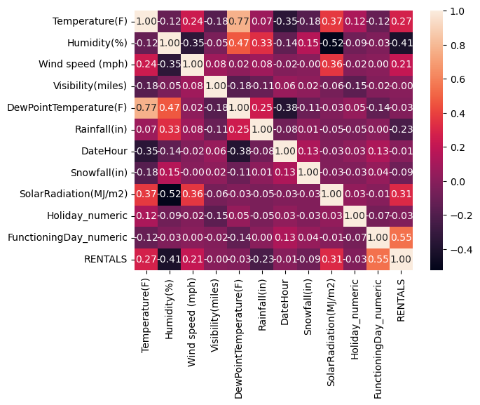

```python
# Plotting a correlation matrix to find out which values affect more the Rentals variable
df_corr = df_full[['Temperature(F)', 'Humidity(%)', 'Wind speed (mph)',
                   'Visibility(miles)', 'DewPointTemperature(F)', 'Rainfall(in)', 'DateHour',
                   'Snowfall(in)', 'SolarRadiation(MJ/m2)', 'Holiday_numeric', 'FunctioningDay_numeric',
                   'RENTALS']].corr(method = 'spearman',
                              numeric_only = False)# to include DateHour variable

sns.heatmap(data = df_corr,
           annot = True,
           fmt   =".2f")
plt.show(block   = True)
```

By plotting scatterplots to see the see the relationship between Rentals and the variables with the strongest correlation we can see that the lower the Humidity(%) the higher the level of rentals and we can also visualize that there are many zeros present that possibly are the no functioning days, conversely, we can observe that the higher the variable SolarRadiation(MJ/m2) , the higher the number of rentals, we can notice a similar amount of zeros possibly due to the same factor.

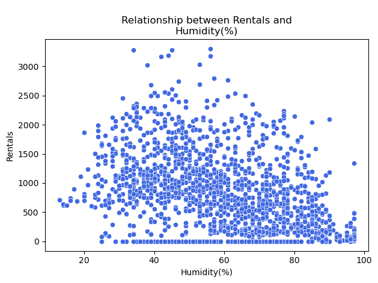

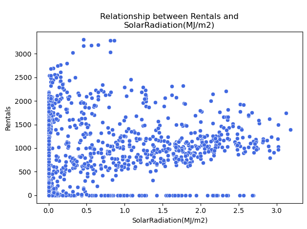

```python
# developing a scatterplot
sns.scatterplot(x     = df_full['Humidity(%)'],
                y     = df_full['RENTALS'], #
                color = 'royalblue')


# title and labels
plt.title(label   = """
Relationship between Rentals and
Humidity(%)""")
plt.xlabel(xlabel = 'Humidity(%)')
plt.ylabel(ylabel = 'Rentals')


# cleaning up layout and rendering visual
plt.tight_layout()
plt.show()

# developing a scatterplot
sns.scatterplot(x     = df_full['SolarRadiation(MJ/m2)'],
                y     = df_full['RENTALS'], #
                color = 'royalblue')


# title and labels
plt.title(label   = """
Relationship between Rentals and
SolarRadiation(MJ/m2)""")
plt.xlabel(xlabel = 'SolarRadiation(MJ/m2)')
plt.ylabel(ylabel = 'Rentals')


# cleaning up layout and rendering visual
plt.tight_layout()
plt.show()
```

### Missing Value Analysis and Imputation

Missing values can negatively affect the model performance and produce inaccurate or biased results. In this process we will analyze how many variables have missing values and develop a strategy to manipulate them.

```python
## Missing Value Imputation ##
missing_values = df_full.isnull().sum()

# Imprimir la cantidad de valores faltantes por columna
print("Missing values per column:")
print(missing_values)
```

```
Missing values per column:
DateHour                    0
Temperature(F)              0
Humidity(%)                 0
Wind speed (mph)            0
Visibility(miles)          76
DewPointTemperature(F)     67
Rainfall(in)                0
Snowfall(in)                0
SolarRadiation(MJ/m2)     106
Holiday                     0
FunctioningDay              0
RENTALS                   546
set                         0
Holiday_numeric             0
FunctioningDay_numeric      0
dtype: int64
```

```python
# looping to flag features with missing values
for col in df_full:

    # creating columns with 1s if missing and 0 if not
    if df_full[col].isnull().astype(int).sum() > 0:
        df_full['mv_'+col] = df_full[col].isnull().astype(int)
```

We see that Visibility(miles), DewPointTemperature(F) and SolarRadiation(MJ/m2) are the X variables containing missing values and Rentals, our Y variable also contains 546 missing values but these are the ones we are aiming to predict.

```python
# checking results - summing missing value flags
df_full[ ['mv_Visibility(miles)', 'mv_DewPointTemperature(F)', 'mv_SolarRadiation(MJ/m2)', 'mv_RENTALS'] ].sum(axis = 0)
```

```
mv_Visibility(miles)          76
mv_DewPointTemperature(F)     67
mv_SolarRadiation(MJ/m2)     106
mv_RENTALS                   546
dtype: int64
```

Now plotting the distributions of the variables with missing values can help us to define which strategy is better to get rid of missing values

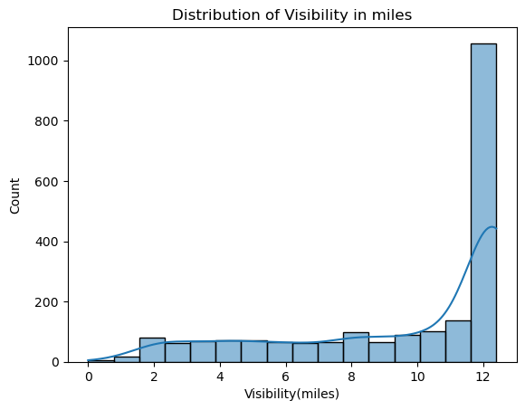

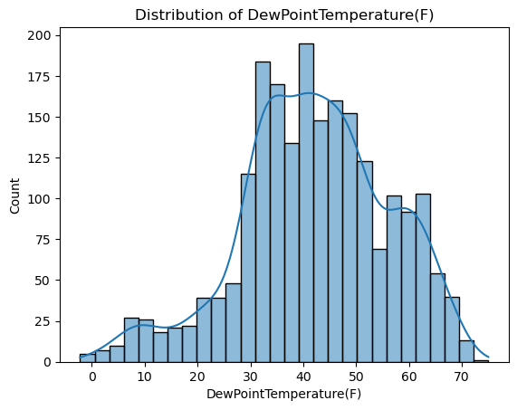

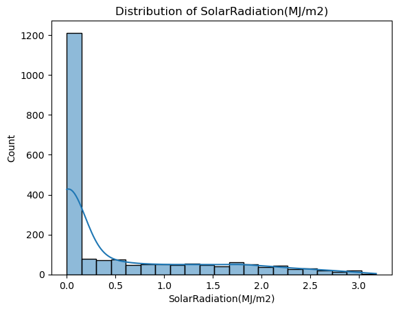

```python
# Plotting 'Visibility(miles)' distribution
sns.histplot(x='Visibility(miles)', data=df_full, kde=True)
plt.title(label='Distribution of Visibility in miles')
plt.xlabel(xlabel='Visibility(miles)')
plt.ylabel(ylabel='Count')
plt.show()

# Plotting 'DewPointTemperature(F)' distribution
sns.histplot(x='DewPointTemperature(F)', data=df_full, kde=True)
plt.title(label='Distribution of DewPointTemperature(F)')
plt.xlabel(xlabel='DewPointTemperature(F)')
plt.ylabel(ylabel='Count')
plt.show()

# Plotting 'SolarRadiation(MJ/m2)' distribution
sns.histplot(x='SolarRadiation(MJ/m2)', data=df_full, kde=True)
plt.title(label='Distribution of SolarRadiation(MJ/m2)')
plt.xlabel(xlabel='SolarRadiation(MJ/m2)')
plt.ylabel(ylabel='Count')
plt.show()
```

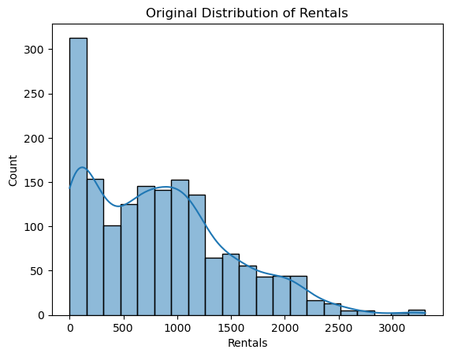

```python
# plotting the distribution of y variable Rentals
sns.histplot(data   = df_full,
             x      = 'RENTALS',
             kde    = True)


# title and axis labels
plt.title(label   = "Original Distribution of Rentals")
plt.xlabel(xlabel = "Rentals")
plt.ylabel(ylabel = "Count")

# displaying the histogram
plt.show()
```

```python
## Imputation ##

# Imputing values of Visibility feature with univariate approach
fill = df_full['Visibility(miles)'].median() #using the median because the distribution is negative skeweed

df_full['Visibility(miles)'].fillna(value   = fill,
                                    inplace = True)

# converting Visibility(miles) into integer type data to avoid decimals
df_full['Visibility(miles)'] = df_full['Visibility(miles)'].astype(int)

# Imputing values of DewPointTemperature(F) feature with univariate approach
fill2 = df_full['DewPointTemperature(F)'].mean() #using the mean since the distribution is more symmetric

df_full['DewPointTemperature(F)'].fillna(value   = fill2,
                                         inplace = True)

# converting DewPointTemperature(F) into integer type data to avoid decimals
df_full['DewPointTemperature(F)'] = df_full['DewPointTemperature(F)'].astype(int)

# Imputing values of SolarRadiation(MJ/m2) feature with univariate approach
fill3 = df_full['SolarRadiation(MJ/m2)'].median()# using the median since the distribution is skewed
df_full['SolarRadiation(MJ/m2)'].fillna(value = fill3,
                                    inplace   = True)

# converting SolarRadiation(MJ/m2) into integer type data to avoid decimals
df_full['SolarRadiation(MJ/m2)'] = df_full['SolarRadiation(MJ/m2)'].astype(int)

# checking results dropping the Rentals variable
df_full.drop(columns=['RENTALS']).isnull().any().any()
```

```
False
```

```python
#droping the added mv_columns from the full dataframe to keep the original columns
df_full = df_full.drop(columns=['mv_Visibility(miles)', 'mv_DewPointTemperature(F)', 'mv_SolarRadiation(MJ/m2)', 'mv_RENTALS'])
```

### Transformations

In this step we will analyze the skewness level contained in the current variables and if it is greater than 1 or less than -1, we will proceed to transform the variables into logarithms to reduce the skewness of the distribution.

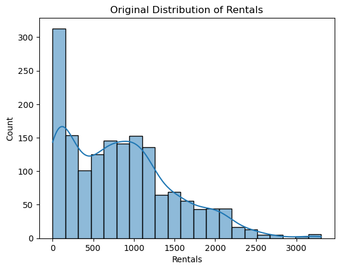

```python
## Transformations ##

# developing a histogram using HISTPLOT to see the distribution of Rentals
sns.histplot(data   = df_full,
             x      = 'RENTALS',
             kde    = True)


# title and axis labels
plt.title(label   = "Original Distribution of Rentals")
plt.xlabel(xlabel = "Rentals") # avoiding using dataset labels
plt.ylabel(ylabel = "Count")

# displaying the histogram
plt.show()
```

```python
# Sort only numeric columns
numeric_columns = df_full.select_dtypes(include='number')

# Calculate skewness only for numeric features
skewness = numeric_columns.skew(axis=0).round(decimals=2)

# Print skewness of numeric columns
for column, skew in skewness.items():
    print(f"{column}: {skew}")
```

```
Temperature(F): 0.04
Humidity(%): 0.02
Wind speed (mph): 1.04
Visibility(miles): -1.06
DewPointTemperature(F): -0.34
Rainfall(in): 11.91
Snowfall(in): 11.45
SolarRadiation(MJ/m2): 1.85
RENTALS: 0.72
Holiday_numeric: 3.91
FunctioningDay_numeric: -2.44
```

Logarithmically transform any X-features that have an absolute skewness value greater than 1.0 or lower than -1.0. excluding Holiday_numeric and FunctioningDay_numeric since this variables store binary values.

```python
# log transforming skewed features
df_full['log_Wind speed (mph)']      = np.log1p(df_full['Wind speed (mph)'])
df_full['log_Visibility(miles)']     = np.log1p(df_full['Visibility(miles)'])
df_full['log_Rainfall(in)']          = np.log1p(df_full['Rainfall(in)'])
df_full['log_Snowfall(in)']          = np.log1p(df_full['Snowfall(in)'])
df_full['log_SolarRadiation(MJ/m2)'] = np.log1p(df_full['SolarRadiation(MJ/m2)'])
```

```python
# imputing SimpleImputer
from sklearn.impute import SimpleImputer


# defining imputation strategy
imp_zero = SimpleImputer(strategy   = 'constant',
                         fill_value = 0)


# transforming to fill in missing values
imputed = imp_zero.fit_transform(df_full)


# converting results into a DataFrame
imputed_df = pd.DataFrame(data = imputed)


# using original dataframe column names
imputed_df.columns = df_full.columns


# overwriting with imputed results
df_full = imputed_df.copy()


# checking results
df_full[ ['Visibility(miles)', 'log_Visibility(miles)'] ].head(n = 5)
```

|  | Visibility(miles) | log_Visibility(miles) |
| --- | --- | --- |
| 0 | 2 | 1.098612 |
| 1 | 11 | 2.484907 |
| 2 | 3 | 1.386294 |
| 3 | 12 | 2.564949 |
| 4 | 10 | 2.397895 |

```python
df_full.head(n = 5)
```

|  | DateHour | Temperature(F) | Humidity(%) | Wind speed (mph) | Visibility(miles) | DewPointTemperature(F) | Rainfall(in) | Snowfall(in) | SolarRadiation(MJ/m2) | Holiday | FunctioningDay | RENTALS | set | Holiday_numeric | FunctioningDay_numeric | log_Wind speed (mph) | log_Visibility(miles) | log_Rainfall(in) | log_Snowfall(in) | log_SolarRadiation(MJ/m2) |
| --- | --- | --- | --- | --- | --- | --- | --- | --- | --- | --- | --- | --- | --- | --- | --- | --- | --- | --- | --- | --- |
| 0 | 2023-10-14 05:59:54.810 | 52 | 81 | 0.4 | 2 | 46 | 0.0 | 0.0 | 0 | No | Yes | 519.0 | Not Kaggle | 0 | 1 | 0.336472 | 1.098612 | 0.0 | 0.0 | 0.0 |
| 1 | 2023-10-26 08:59:53.355 | 51 | 53 | 2.2 | 11 | 35 | 0.0 | 0.0 | 1 | No | Yes | 1251.0 | Not Kaggle | 0 | 1 | 1.163151 | 2.484907 | 0.0 | 0.0 | 0.693147 |
| 2 | 2023-09-23 21:59:57.250 | 56 | 49 | 2.5 | 3 | 38 | 0.0 | 0.0 | 0 | No | Yes | 1685.0 | Not Kaggle | 0 | 1 | 1.252763 | 1.386294 | 0.0 | 0.0 | 0.0 |
| 3 | 2023-12-19 14:00:00.000 | 69 | 32 | 9.8 | 12 | 38 | 0.0 | 0.0 | 2 | No | No | 0.0 | Not Kaggle | 0 | 0 | 2.379546 | 2.564949 | 0.0 | 0.0 | 1.098612 |
| 4 | 2023-10-30 12:59:52.855 | 53 | 20 | 2.9 | 10 | 12 | 0.0 | 0.0 | 1 | No | Yes | 814.0 | Not Kaggle | 0 | 1 | 1.360977 | 2.397895 | 0.0 | 0.0 | 0.693147 |

```python
# skewness AFTER logarithmic transformations
df_full.loc[ : , 'log_Wind speed (mph)': ].skew(axis = 0).sort_index(ascending = False)
```

```
log_Wind speed (mph)         -0.343629
log_Visibility(miles)        -1.749532
log_SolarRadiation(MJ/m2)     1.520685
log_Snowfall(in)             10.933476
log_Rainfall(in)             10.658102
dtype: object
```

### Feature Engineering

Solar_Humidity_Ratio: This new feature that is calculated from the division of two existing variables SolarRadiation(MJ/m2) and Humidity(%), being the numerical variables with the strongest correlation in the whole dataset, in the same way we add a small value close to zero (epsilon) to make the calculation, and when it is high, it can indicate a relatively high proportion of solar radiation compared to humidity. This could indicate sunnier and drier climatic conditions, as we saw in the scatterplots, the lower the Humidity(%), the higher the rents and the higher the SolarRadiation(MJ/m2) the higher the rents as well.

Solar_Wind_Ratio: For this new variable we use SolarRadiation(MJ/m2) and Wind speed (mph), since Wind speed (mph) has a positive correlation of 21% with rentals, combining these two variables with strong correlation could indicate sunnier and less windy weather conditions when it is high, and when it is low it would indicate less sunny and windier conditions.

```python
# adding a small number close to zero to avoid getting infinite or null values
epsilon = 1e-10  # Small value of epsilon

#df_full['Temp_Humidity_Ratio'] = df_full['Temperature(F)'] / df_full['Humidity(%)']
df_full['Temp_Humidity_Ratio'] = df_full['Temperature(F)'] / (df_full['Humidity(%)'] + epsilon)
df_full['Solar_Humidity_Ratio'] = df_full['SolarRadiation(MJ/m2)'] / (df_full['Humidity(%)'] + epsilon)
df_full['Solar_Wind_Ratio'] = df_full['SolarRadiation(MJ/m2)'] / (df_full['Wind speed (mph)'] + epsilon)
```

```python
df_full.head(n = 5)
```

|  | DateHour | Temperature(F) | Humidity(%) | Wind speed (mph) | Visibility(miles) | DewPointTemperature(F) | Rainfall(in) | Snowfall(in) | SolarRadiation(MJ/m2) | Holiday | FunctioningDay | RENTALS | set | Holiday_numeric | FunctioningDay_numeric | log_Wind speed (mph) | log_Visibility(miles) | log_Rainfall(in) | log_Snowfall(in) | log_SolarRadiation(MJ/m2) | Temp_Humidity_Ratio | Solar_Humidity_Ratio | Solar_Wind_Ratio |
| --- | --- | --- | --- | --- | --- | --- | --- | --- | --- | --- | --- | --- | --- | --- | --- | --- | --- | --- | --- | --- | --- | --- | --- |
| 0 | 2023-10-14 05:59:54.810 | 52 | 81 | 0.4 | 2 | 46 | 0.0 | 0.0 | 0 | No | Yes | 519.0 | Not Kaggle | 0 | 1 | 0.336472 | 1.098612 | 0.0 | 0.0 | 0.0 | 0.641975 | 0.0 | 0.0 |
| 1 | 2023-10-26 08:59:53.355 | 51 | 53 | 2.2 | 11 | 35 | 0.0 | 0.0 | 1 | No | Yes | 1251.0 | Not Kaggle | 0 | 1 | 1.163151 | 2.484907 | 0.0 | 0.0 | 0.693147 | 0.962264 | 0.018868 | 0.454545 |
| 2 | 2023-09-23 21:59:57.250 | 56 | 49 | 2.5 | 3 | 38 | 0.0 | 0.0 | 0 | No | Yes | 1685.0 | Not Kaggle | 0 | 1 | 1.252763 | 1.386294 | 0.0 | 0.0 | 0.0 | 1.142857 | 0.0 | 0.0 |
| 3 | 2023-12-19 14:00:00.000 | 69 | 32 | 9.8 | 12 | 38 | 0.0 | 0.0 | 2 | No | No | 0.0 | Not Kaggle | 0 | 0 | 2.379546 | 2.564949 | 0.0 | 0.0 | 1.098612 | 2.15625 | 0.0625 | 0.204082 |
| 4 | 2023-10-30 12:59:52.855 | 53 | 20 | 2.9 | 10 | 12 | 0.0 | 0.0 | 1 | No | Yes | 814.0 | Not Kaggle | 0 | 1 | 1.360977 | 2.397895 | 0.0 | 0.0 | 0.693147 | 2.65 | 0.05 | 0.344828 |

### Standardization

```python
df_full.head(n = 5)
```

|  | DateHour | Temperature(F) | Humidity(%) | Wind speed (mph) | Visibility(miles) | DewPointTemperature(F) | Rainfall(in) | Snowfall(in) | SolarRadiation(MJ/m2) | Holiday | FunctioningDay | RENTALS | set | Holiday_numeric | FunctioningDay_numeric | log_Wind speed (mph) | log_Visibility(miles) | log_Rainfall(in) | log_Snowfall(in) | log_SolarRadiation(MJ/m2) | Temp_Humidity_Ratio | Solar_Humidity_Ratio | Solar_Wind_Ratio |
| --- | --- | --- | --- | --- | --- | --- | --- | --- | --- | --- | --- | --- | --- | --- | --- | --- | --- | --- | --- | --- | --- | --- | --- |
| 0 | 2023-10-14 05:59:54.810 | 52 | 81 | 0.4 | 2 | 46 | 0.0 | 0.0 | 0 | No | Yes | 519.0 | Not Kaggle | 0 | 1 | 0.336472 | 1.098612 | 0.0 | 0.0 | 0.0 | 0.641975 | 0.0 | 0.0 |
| 1 | 2023-10-26 08:59:53.355 | 51 | 53 | 2.2 | 11 | 35 | 0.0 | 0.0 | 1 | No | Yes | 1251.0 | Not Kaggle | 0 | 1 | 1.163151 | 2.484907 | 0.0 | 0.0 | 0.693147 | 0.962264 | 0.018868 | 0.454545 |
| 2 | 2023-09-23 21:59:57.250 | 56 | 49 | 2.5 | 3 | 38 | 0.0 | 0.0 | 0 | No | Yes | 1685.0 | Not Kaggle | 0 | 1 | 1.252763 | 1.386294 | 0.0 | 0.0 | 0.0 | 1.142857 | 0.0 | 0.0 |
| 3 | 2023-12-19 14:00:00.000 | 69 | 32 | 9.8 | 12 | 38 | 0.0 | 0.0 | 2 | No | No | 0.0 | Not Kaggle | 0 | 0 | 2.379546 | 2.564949 | 0.0 | 0.0 | 1.098612 | 2.15625 | 0.0625 | 0.204082 |
| 4 | 2023-10-30 12:59:52.855 | 53 | 20 | 2.9 | 10 | 12 | 0.0 | 0.0 | 1 | No | Yes | 814.0 | Not Kaggle | 0 | 1 | 1.360977 | 2.397895 | 0.0 | 0.0 | 0.693147 | 2.65 | 0.05 | 0.344828 |

```python
# preparing explanatory variable data
df_full_std = df_full.drop(['DateHour',
                            'set',
                            'RENTALS',
                            'FunctioningDay',
                            'Holiday'],
                           axis = 1)
```

```python
## Standardization ##

# INSTANTIATING a StandardScaler() object
scaler = StandardScaler()


# FITTING the scaler with the data
scaler.fit(df_full_std)


# TRANSFORMING our data after fit
x_scaled = scaler.transform(df_full_std)


# converting scaled data into a DataFrame
x_scaled_df = pd.DataFrame(x_scaled)


# checking the results
x_scaled_df.describe(include = 'number').round(decimals = 2)
```

|  | 0 | 1 | 2 | 3 | 4 | 5 | 6 | 7 | 8 | 9 | 10 | 11 | 12 | 13 | 14 | 15 | 16 | 17 |
| --- | --- | --- | --- | --- | --- | --- | --- | --- | --- | --- | --- | --- | --- | --- | --- | --- | --- | --- |
| count | 2184.00 | 2184.00 | 2184.00 | 2184.00 | 2184.00 | 2184.00 | 2184.00 | 2184.00 | 2184.00 | 2184.00 | 2184.00 | 2184.00 | 2184.00 | 2184.00 | 2184.00 | 2184.00 | 2184.00 | 2184.00 |
| mean | 0.00 | -0.00 | -0.00 | 0.00 | -0.00 | -0.00 | -0.00 | -0.00 | -0.00 | 0.00 | 0.00 | 0.00 | -0.00 | 0.00 | 0.00 | -0.00 | 0.00 | -0.00 |
| std | 1.00 | 1.00 | 1.00 | 1.00 | 1.00 | 1.00 | 1.00 | 1.00 | 1.00 | 1.00 | 1.00 | 1.00 | 1.00 | 1.00 | 1.00 | 1.00 | 1.00 | 1.00 |
| min | -2.44 | -2.47 | -1.62 | -2.67 | -3.17 | -0.13 | -0.11 | -0.51 | -0.24 | -2.80 | -2.76 | -4.54 | -0.14 | -0.11 | -0.53 | -1.50 | -0.48 | -0.47 |
| 25% | -0.73 | -0.82 | -0.75 | -0.66 | -0.63 | -0.13 | -0.11 | -0.51 | -0.24 | 0.36 | -0.66 | -0.32 | -0.14 | -0.11 | -0.53 | -0.73 | -0.48 | -0.47 |
| 50% | -0.03 | -0.01 | -0.21 | 0.49 | 0.03 | -0.13 | -0.11 | -0.51 | -0.24 | 0.36 | 0.01 | 0.50 | -0.14 | -0.11 | -0.53 | -0.30 | -0.48 | -0.47 |
| 75% | 0.83 | 0.79 | 0.56 | 0.78 | 0.68 | -0.13 | -0.11 | -0.51 | -0.24 | 0.36 | 0.71 | 0.66 | -0.14 | -0.11 | -0.53 | 0.44 | -0.48 | -0.47 |
| max | 2.61 | 2.02 | 4.57 | 0.78 | 2.42 | 18.88 | 16.07 | 4.21 | 4.15 | 0.36 | 2.59 | 0.66 | 17.10 | 15.48 | 3.20 | 4.88 | 5.31 | 9.22 |

```python
# adding labels to the scaled DataFrame
x_scaled_df.columns = df_full_std.columns

#  Checking pre- and post-scaling of the data
print(f"""
Dataset BEFORE Scaling
----------------------
{np.var(df_full_std)}


Dataset AFTER Scaling
----------------------
{np.var(x_scaled_df)}
""")
```

```
Dataset BEFORE Scaling
----------------------
Temperature(F)               165.346798
Humidity(%)                  349.023346
Wind speed (mph)               4.287674
Visibility(miles)             12.066487
DewPointTemperature(F)       189.658052
Rainfall(in)                   0.001395
Snowfall(in)                   0.000344
SolarRadiation(MJ/m2)          0.404822
Holiday_numeric                0.051926
FunctioningDay_numeric         0.100305
log_Wind speed (mph)           0.240506
log_Visibility(miles)          0.243616
log_Rainfall(in)               0.000969
log_Snowfall(in)               0.000283
log_SolarRadiation(MJ/m2)      0.138147
Temp_Humidity_Ratio            0.271733
Solar_Humidity_Ratio           0.000319
Solar_Wind_Ratio               0.035271
dtype: object


Dataset AFTER Scaling
----------------------
Temperature(F)               1.0
Humidity(%)                  1.0
Wind speed (mph)             1.0
Visibility(miles)            1.0
DewPointTemperature(F)       1.0
Rainfall(in)                 1.0
Snowfall(in)                 1.0
SolarRadiation(MJ/m2)        1.0
Holiday_numeric              1.0
FunctioningDay_numeric       1.0
log_Wind speed (mph)         1.0
log_Visibility(miles)        1.0
log_Rainfall(in)             1.0
log_Snowfall(in)             1.0
log_SolarRadiation(MJ/m2)    1.0
Temp_Humidity_Ratio          1.0
Solar_Humidity_Ratio         1.0
Solar_Wind_Ratio             1.0
dtype: float64
```

## Part III: Data Partitioning

This is a very important step for your submission on Kaggle. Make sure to complete your data preparationbefore moving forward.

### Separating the Kaggle Data

```python
df_full.head()
```

|  | DateHour | Temperature(F) | Humidity(%) | Wind speed (mph) | Visibility(miles) | DewPointTemperature(F) | Rainfall(in) | Snowfall(in) | SolarRadiation(MJ/m2) | Holiday | FunctioningDay | RENTALS | set | Holiday_numeric | FunctioningDay_numeric | log_Wind speed (mph) | log_Visibility(miles) | log_Rainfall(in) | log_Snowfall(in) | log_SolarRadiation(MJ/m2) | Temp_Humidity_Ratio | Solar_Humidity_Ratio | Solar_Wind_Ratio |
| --- | --- | --- | --- | --- | --- | --- | --- | --- | --- | --- | --- | --- | --- | --- | --- | --- | --- | --- | --- | --- | --- | --- | --- |
| 0 | 2023-10-14 05:59:54.810 | 52 | 81 | 0.4 | 2 | 46 | 0.0 | 0.0 | 0 | No | Yes | 519.0 | Not Kaggle | 0 | 1 | 0.336472 | 1.098612 | 0.0 | 0.0 | 0.0 | 0.641975 | 0.0 | 0.0 |
| 1 | 2023-10-26 08:59:53.355 | 51 | 53 | 2.2 | 11 | 35 | 0.0 | 0.0 | 1 | No | Yes | 1251.0 | Not Kaggle | 0 | 1 | 1.163151 | 2.484907 | 0.0 | 0.0 | 0.693147 | 0.962264 | 0.018868 | 0.454545 |
| 2 | 2023-09-23 21:59:57.250 | 56 | 49 | 2.5 | 3 | 38 | 0.0 | 0.0 | 0 | No | Yes | 1685.0 | Not Kaggle | 0 | 1 | 1.252763 | 1.386294 | 0.0 | 0.0 | 0.0 | 1.142857 | 0.0 | 0.0 |
| 3 | 2023-12-19 14:00:00.000 | 69 | 32 | 9.8 | 12 | 38 | 0.0 | 0.0 | 2 | No | No | 0.0 | Not Kaggle | 0 | 0 | 2.379546 | 2.564949 | 0.0 | 0.0 | 1.098612 | 2.15625 | 0.0625 | 0.204082 |
| 4 | 2023-10-30 12:59:52.855 | 53 | 20 | 2.9 | 10 | 12 | 0.0 | 0.0 | 1 | No | Yes | 814.0 | Not Kaggle | 0 | 1 | 1.360977 | 2.397895 | 0.0 | 0.0 | 0.693147 | 2.65 | 0.05 | 0.344828 |

```python
## parsing out testing data (needed for later) ##

# dataset for kaggle
kaggle_data = df_full[ df_full['set'] == 'Kaggle' ].copy()


# dataset for model building
df = df_full[ df_full['set'] == 'Not Kaggle' ].copy()


# dropping set identifier (kaggle)
kaggle_data.drop(labels = 'set',
                 axis = 1,
                 inplace = True)


# dropping set identifier (model building)
df.drop(labels = 'set',
        axis = 1,
        inplace = True)
```

```python
df.head()
```

|  | DateHour | Temperature(F) | Humidity(%) | Wind speed (mph) | Visibility(miles) | DewPointTemperature(F) | Rainfall(in) | Snowfall(in) | SolarRadiation(MJ/m2) | Holiday | FunctioningDay | RENTALS | Holiday_numeric | FunctioningDay_numeric | log_Wind speed (mph) | log_Visibility(miles) | log_Rainfall(in) | log_Snowfall(in) | log_SolarRadiation(MJ/m2) | Temp_Humidity_Ratio | Solar_Humidity_Ratio | Solar_Wind_Ratio |
| --- | --- | --- | --- | --- | --- | --- | --- | --- | --- | --- | --- | --- | --- | --- | --- | --- | --- | --- | --- | --- | --- | --- |
| 0 | 2023-10-14 05:59:54.810 | 52 | 81 | 0.4 | 2 | 46 | 0.0 | 0.0 | 0 | No | Yes | 519.0 | 0 | 1 | 0.336472 | 1.098612 | 0.0 | 0.0 | 0.0 | 0.641975 | 0.0 | 0.0 |
| 1 | 2023-10-26 08:59:53.355 | 51 | 53 | 2.2 | 11 | 35 | 0.0 | 0.0 | 1 | No | Yes | 1251.0 | 0 | 1 | 1.163151 | 2.484907 | 0.0 | 0.0 | 0.693147 | 0.962264 | 0.018868 | 0.454545 |
| 2 | 2023-09-23 21:59:57.250 | 56 | 49 | 2.5 | 3 | 38 | 0.0 | 0.0 | 0 | No | Yes | 1685.0 | 0 | 1 | 1.252763 | 1.386294 | 0.0 | 0.0 | 0.0 | 1.142857 | 0.0 | 0.0 |
| 3 | 2023-12-19 14:00:00.000 | 69 | 32 | 9.8 | 12 | 38 | 0.0 | 0.0 | 2 | No | No | 0.0 | 0 | 0 | 2.379546 | 2.564949 | 0.0 | 0.0 | 1.098612 | 2.15625 | 0.0625 | 0.204082 |
| 4 | 2023-10-30 12:59:52.855 | 53 | 20 | 2.9 | 10 | 12 | 0.0 | 0.0 | 1 | No | Yes | 814.0 | 0 | 1 | 1.360977 | 2.397895 | 0.0 | 0.0 | 0.693147 | 2.65 | 0.05 | 0.344828 |

### Train-Test Split

Note that the following code will remove non-numeric features, keeping only integer and float data types. It will also remove any observations that contain missing values. This is to prevent errors in the model building process.

```python
#!##############################!#
#!# set your response variable #!#
#!##############################!#
y_variable = "RENTALS"


#!###########################!#
#!# choose your x-variables #!#
#!###########################!#

#transforming the x_features to integer
columns_to_convert = ['Temperature(F)', 'Humidity(%)', 'Wind speed (mph)',
                      'SolarRadiation(MJ/m2)', 'FunctioningDay_numeric',
                      'Temp_Humidity_Ratio', 'Solar_Humidity_Ratio', 'Solar_Wind_Ratio']

df[columns_to_convert] = df[columns_to_convert].astype(int)

x_features = [ 'Temperature(F)', 'Humidity(%)', 'Wind speed (mph)', 'SolarRadiation(MJ/m2)',
              'Temp_Humidity_Ratio', 'Solar_Humidity_Ratio', 'Solar_Wind_Ratio'] # this should be a list
```

```python
df[x_features] = df[x_features].astype(int)
```

```python
# Checking that all x_features are converted to integer
print(df[['Temperature(F)', 'Humidity(%)', 'Wind speed (mph)', 'SolarRadiation(MJ/m2)', 'FunctioningDay_numeric']].dtypes)
```

```
Temperature(F)            int64
Humidity(%)               int64
Wind speed (mph)          int64
SolarRadiation(MJ/m2)     int64
FunctioningDay_numeric    int64
dtype: object
```

```python
## ########################### ##
## DON'T CHANGE THE CODE BELOW ##
## ########################### ##

# prepping data for train-test split
y_data = df[y_variable]


# removing non-numeric columns and missing values
x_data = df[x_features].copy().select_dtypes(include=[int, float]).dropna(axis = 1)


# storing remaining x_features after the step above
x_features = list(x_data.columns)


# train-test split (to validate the model)
x_train, x_test, y_train, y_test = train_test_split(x_data,
                                                    y_data,
                                                    test_size    = 0.25,
                                                    random_state = 702 )


# results of train-test split
print(f"""
Original Dataset Dimensions
---------------------------
Observations (Rows): {df.shape[0]}
Features  (Columns): {df.shape[1]}


Training Data (X-side)
----------------------
Observations (Rows): {x_train.shape[0]}
Features  (Columns): {x_train.shape[1]}


Training Data (y-side)
----------------------
Feature Name:        {y_train.name}
Observations (Rows): {y_train.shape[0]}


Testing Data (X-side)
---------------------
Observations (Rows): {x_test.shape[0]}
Features  (Columns): {x_test.shape[1]}


Testing Data (y-side)
---------------------
Feature Name:        {y_test.name}
Observations (Rows): {y_test.shape[0]}""")
```

```
Original Dataset Dimensions
---------------------------
Observations (Rows): 1638
Features  (Columns): 22


Training Data (X-side)
----------------------
Observations (Rows): 1228
Features  (Columns): 7


Training Data (y-side)
----------------------
Feature Name:        RENTALS
Observations (Rows): 1228


Testing Data (X-side)
---------------------
Observations (Rows): 410
Features  (Columns): 7


Testing Data (y-side)
---------------------
Feature Name:        RENTALS
Observations (Rows): 410
```

```python
df_full.head()
```

|  | DateHour | Temperature(F) | Humidity(%) | Wind speed (mph) | Visibility(miles) | DewPointTemperature(F) | Rainfall(in) | Snowfall(in) | SolarRadiation(MJ/m2) | Holiday | FunctioningDay | RENTALS | set | Holiday_numeric | FunctioningDay_numeric | log_Wind speed (mph) | log_Visibility(miles) | log_Rainfall(in) | log_Snowfall(in) | log_SolarRadiation(MJ/m2) | Temp_Humidity_Ratio | Solar_Humidity_Ratio | Solar_Wind_Ratio |
| --- | --- | --- | --- | --- | --- | --- | --- | --- | --- | --- | --- | --- | --- | --- | --- | --- | --- | --- | --- | --- | --- | --- | --- |
| 0 | 2023-10-14 05:59:54.810 | 52 | 81 | 0.4 | 2 | 46 | 0.0 | 0.0 | 0 | No | Yes | 519.0 | Not Kaggle | 0 | 1 | 0.336472 | 1.098612 | 0.0 | 0.0 | 0.0 | 0.641975 | 0.0 | 0.0 |
| 1 | 2023-10-26 08:59:53.355 | 51 | 53 | 2.2 | 11 | 35 | 0.0 | 0.0 | 1 | No | Yes | 1251.0 | Not Kaggle | 0 | 1 | 1.163151 | 2.484907 | 0.0 | 0.0 | 0.693147 | 0.962264 | 0.018868 | 0.454545 |
| 2 | 2023-09-23 21:59:57.250 | 56 | 49 | 2.5 | 3 | 38 | 0.0 | 0.0 | 0 | No | Yes | 1685.0 | Not Kaggle | 0 | 1 | 1.252763 | 1.386294 | 0.0 | 0.0 | 0.0 | 1.142857 | 0.0 | 0.0 |
| 3 | 2023-12-19 14:00:00.000 | 69 | 32 | 9.8 | 12 | 38 | 0.0 | 0.0 | 2 | No | No | 0.0 | Not Kaggle | 0 | 0 | 2.379546 | 2.564949 | 0.0 | 0.0 | 1.098612 | 2.15625 | 0.0625 | 0.204082 |
| 4 | 2023-10-30 12:59:52.855 | 53 | 20 | 2.9 | 10 | 12 | 0.0 | 0.0 | 1 | No | Yes | 814.0 | Not Kaggle | 0 | 1 | 1.360977 | 2.397895 | 0.0 | 0.0 | 0.693147 | 2.65 | 0.05 | 0.344828 |

## Part III: Candidate Modeling

Develop your candidate models below.

```python
## Candidate Modeling ##

# naming the model
model_name = 'KNN Rentals Regressor' # name your model

# model type
#model = sklearn.linear_model.KNeighborsRegressor() # model type ( ex: sklearn.linear_model.LinearRegression() )
model = KNeighborsRegressor(algorithm   = 'auto',
                           n_neighbors = 13 )
```

```python
## ########################### ##
## DON'T CHANGE THE CODE BELOW ##
## ########################### ##

# FITTING to the training data
model_fit = model.fit(x_train, y_train)


# PREDICTING on new data
model_pred = model.predict(x_test)


# SCORING the results
model_train_score = model.score(x_train, y_train).round(4)
model_test_score  = model.score(x_test, y_test).round(4)
model_gap         = abs(model_train_score - model_test_score).round(4)


# dynamically printing results
model_summary =  f"""\
Model Name:     {model_name}
Train_Score:    {model_train_score}
Test_Score:     {model_test_score}
Train-Test Gap: {model_gap}
"""

print(model_summary)
```

```
Model Name:     KNN Rentals Regressor
Train_Score:    0.3512
Test_Score:     0.2455
Train-Test Gap: 0.1057
```

### Model Results

Remember that some models have coefficients, visual outputs, etc. Make sure to analyze relevant results for the models you build.

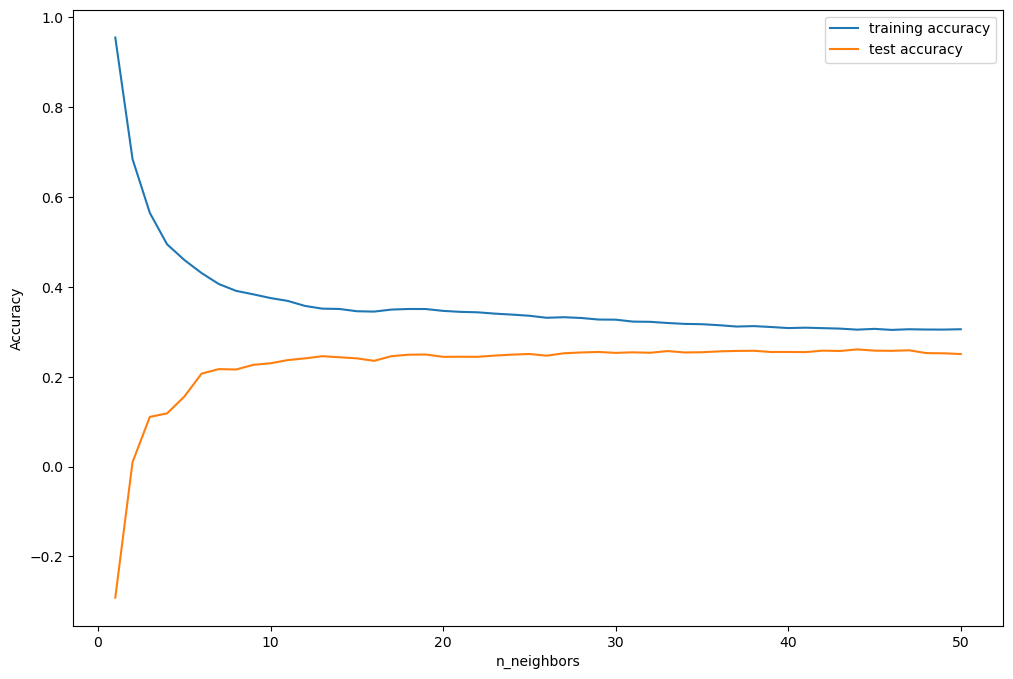

```python
## Model Results ##

# creating lists for training set accuracy and test set accuracy
training_accuracy = []
test_accuracy     = []


# building a visualization of 1 to 50 neighbors
neighbors_settings = range(1, 51)


for n_neighbors in neighbors_settings:
    # Building the model
    clf = KNeighborsRegressor(n_neighbors = n_neighbors)
    clf.fit(x_train, y_train)

    # Recording the training set accuracy
    training_accuracy.append(clf.score(x_train, y_train))

    # Recording the generalization accuracy
    test_accuracy.append(clf.score(x_test, y_test))


# plotting the visualization
fig, ax = plt.subplots(figsize=(12,8))
plt.plot(neighbors_settings, training_accuracy, label = "training accuracy")
plt.plot(neighbors_settings, test_accuracy, label = "test accuracy")
plt.ylabel("Accuracy")
plt.xlabel("n_neighbors")
plt.legend()
plt.show()
```

```python
# finding the optimal number of neighbors
opt_neighbors = test_accuracy.index(max(test_accuracy)) + 1
print(f"""The optimal number of neighbors is {opt_neighbors}""")
```

```
The optimal number of neighbors is 44
```

### Residual Analysis

```python
## Residual Analysis ##

# organizing residuals
model_residuals = {"True"            : y_test,
                   "Predicted"       : model_pred
                  }


# converting residuals into df
model_resid_df = pd.DataFrame(data = model_residuals)


# checking results
model_resid_df.head(n = 5)


#!###########################!#
#!# add more code as needed #!#
#!###########################!#
```

|  | True | Predicted |
| --- | --- | --- |
| 475 | 908.0 | 727.615385 |
| 573 | 131.0 | 142.923077 |
| 80 | 1208.0 | 1154.615385 |
| 202 | 291.0 | 693.461538 |
| 52 | 1433.0 | 679.769231 |

### Hyperparameter Tuning

```python
help(KNeighborsRegressor)
```

[output not shown]

[output cut: 306 more lines]

[output not shown]

```python
# naming the model
model_name = "KNeighbors Regressor"


# INSTANTIATING a logistic regression model with tuned values
model = KNeighborsRegressor(algorithm   = 'auto',
                            n_neighbors  = 44,
                            weights      = "uniform",
                            metric       = 'manhattan',
                            leaf_size    = 20)


# FITTING to the TRAINING data
model.fit(x_train, y_train)


# PREDICTING based on the testing set
model.predict(x_test)


# SCORING results
model_train_score = model.score(x_train, y_train).round(4)
model_test_score  = model.score(x_test, y_test).round(4)
model_gap         = abs(model_train_score - model_test_score).round(4)


# displaying results
print('Training Score :', model_train_score)
print('Testing Score  :', model_test_score)
print('Train-Test Gap :', model_gap)
```

```
Training Score : 0.3149
Testing Score  : 0.2641
Train-Test Gap : 0.0508
```